# Tanja Eberhardt: Fitnessbarometer Baden-Württemberg

Author

Reinhold Kliegl

Published

September 17, 2022

# 1 Background

- Projekt in Zusammenarbeit mit der Kinderturnstiftung Baden-Württemberg und der Odwin gGmbH
- Präsentation der aktuellen Ergebnisse zur körperlichen Leistungsfähigkeit von 28,427 Kindern in BaWü
- Wie hat sich die motorische Leistungsfähigkeit/ einzelne Dimensionen/ einzelne TA in den letzten 10 Jahren (2012-2021) entwickelt?

# 2 Preprocessing

## 2.1 RK style guide

- Random factors should be factors, not integers!
- Factors capitalized, continuous variables in lower case
- `Subj` instead of `ID`; prefix subject and item numbers with `S` and `I`
- Short variable names and factor levels, but respect tradeoff with mmemonic value
- Labels should be of equal length
- Hint: Leave out vowels in names and labels
- See Jenny Bryan’s [Naming Things](https://docplayer.net/55248970-Naming-things-prepared-by-jenny-bryan-for-reproducible-science-workshop.html)

## 2.2 Packages

```r
library(easystats)
library(tidyverse)
library(readxl)
library(lme4)
library(hypr)
library(summarytools)
# respecting color vision deficiency
cbPalette <- c( "#0072B2", "#D55E00", "#009E73", "#CC79A7",
                "#F0E442", "#56B4E9", "#999999", "#E69F00")
```

## 2.3 Read and transform data

```r
dat_w <-
   read_excel("EBERHARDT.xlsx") |>
   select(Child=20,  Source=17, Event=18, Test=19, cohort=1,  District=3, LK=21, PLZ,
          age=4, Sex=5, BMI=50, height=6,  mass=7, bmi=8,
          s20_r=9, bbw=10, lsj=11, sar=12, pu=13, su=14, slj=15, run=16) |>
   mutate(Child=factor(paste0("C", Child)),
          Source=factor(Source),
          Event=factor(paste0("E", str_pad(Event, width = 5, side = "left", pad = "0"))),
          Event=na_if(Event, "ENA"),
          Test=factor(paste0("T", str_pad(as.character(Test), width = 5, side = "left", pad = "0"))),
          District=(fct_recode(factor(District), "FR"="1", "KA"="2", "S"="3", "TÜ"="4")),
          LK=factor(paste0("LK", LK)),
          PLZ=factor(paste0("PLZ", PLZ)),
          s20_r = 20/s20_r ) |>
   filter(between(age, 6, 10))

stview(dfSummary(dat_w))
```

```
Switching method to 'browser'
```

```
Output file written: /var/folders/nd/l59kkqd951xdb29k4rt4yzj80000gn/T//RtmpKRj2gu/file101ff78cc0f40.html
```

**Questions**

- Longitudinal children?
- Filter for plausible values (e.g., 0 for pu, su, bbw)

# 3 Transformations

## 3.1 Check tests

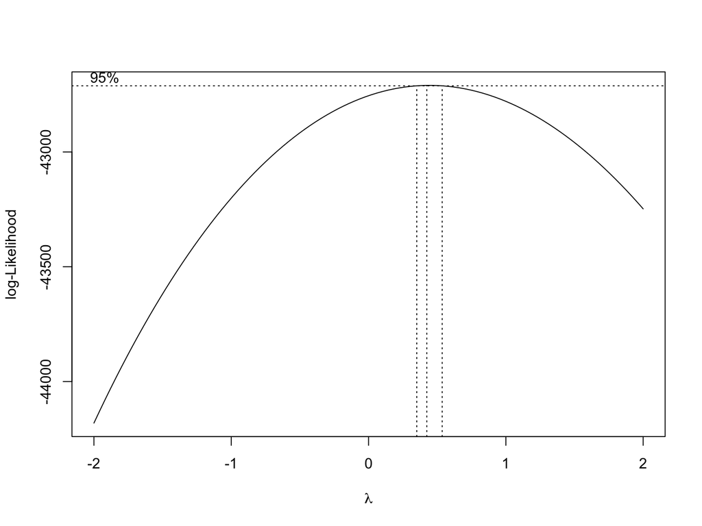

```r
datx <- dat_w |> filter(!is.na(s20_r))
MASS::boxcox(s20_r ~ 1 + age + Sex + bmi, data=datx)
```

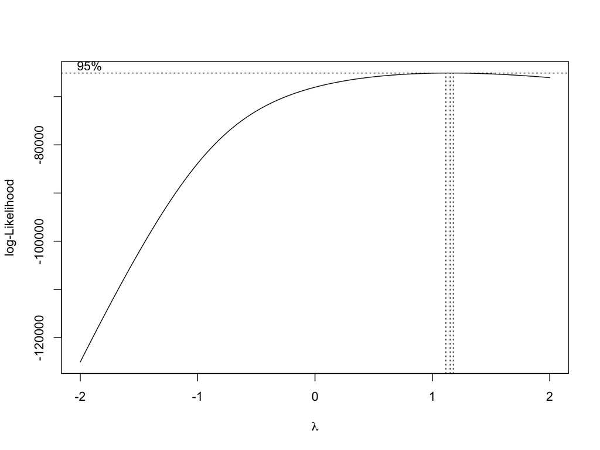

```r
datx <- dat_w |> filter(!is.na(bbw))
MASS::boxcox(bbw+1 ~ 1 + age + Sex + bmi, data=datx)
```

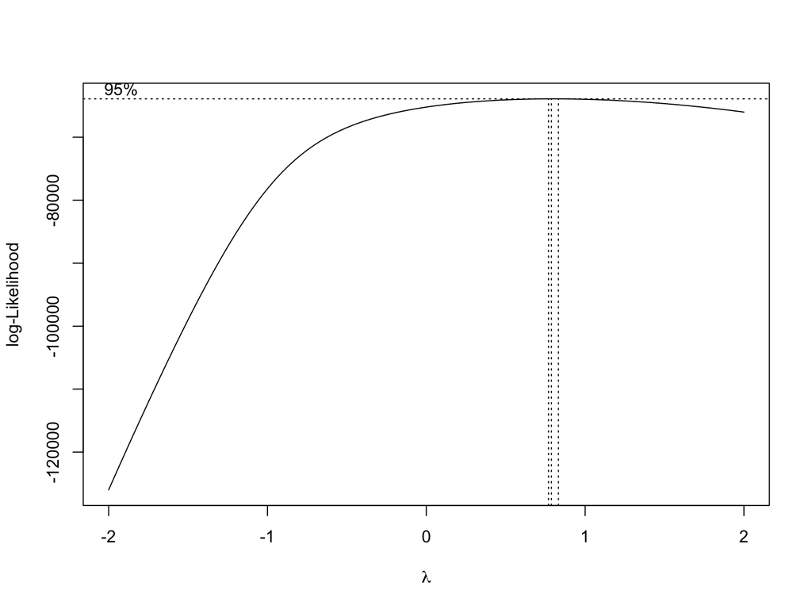

```r
datx <- dat_w |> filter(!is.na(lsj))
MASS::boxcox(lsj ~ 1 + age + Sex + bmi, data=datx)
```

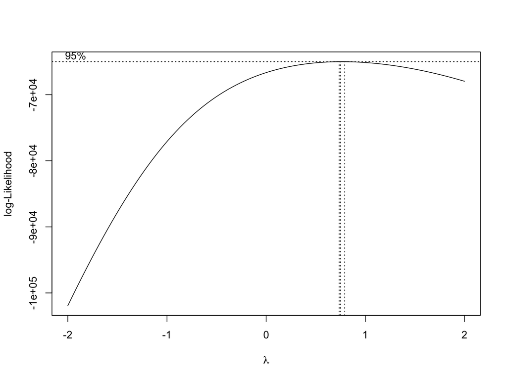

```r
datx <- dat_w |> filter(!is.na(pu))
MASS::boxcox(pu+1 ~ 1 + age + Sex + bmi, data=datx)
```

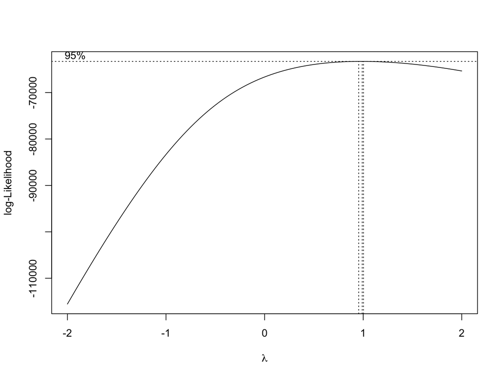

```r
datx <- dat_w |> filter(!is.na(su))
MASS::boxcox(su+1 ~ 1 + age + Sex + bmi, data=datx)
```

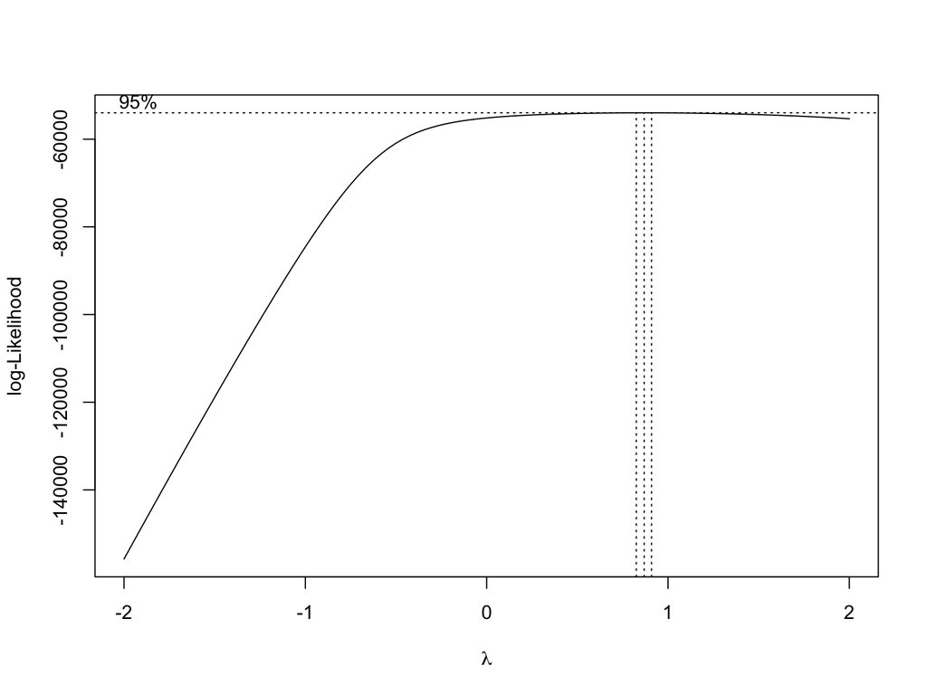

```r
datx <- dat_w |> filter(!is.na(slj))
MASS::boxcox(slj ~ 1 + age + Sex + bmi, data=datx)
```

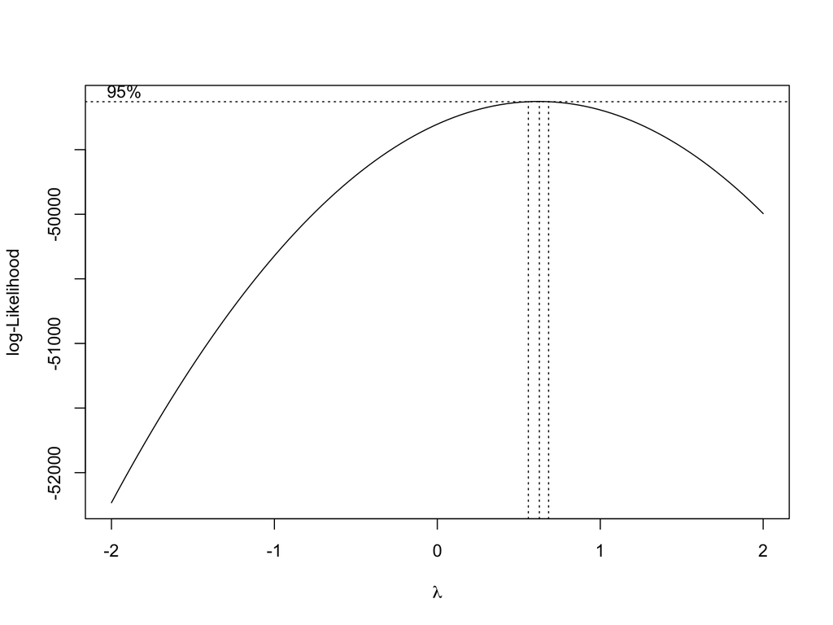

```r
datx <- dat_w |> filter(!is.na(run))
MASS::boxcox(run ~ 1 + age + Sex + bmi, data=datx)
```

## 3.2 From wide to long format

```r
dat <- dat_w %>%
  select(cohort, District, LK, PLZ, Event, Child, Sex,  age,
                bmi, s20_r, bbw, lsj, sar, pu, su, slj, run) |>
  pivot_longer(s20_r:run, names_to = "Test", values_to = "score", values_drop_na = TRUE) |>
  mutate(Sex = factor(Sex),
         Test = factor(Test,
                       levels=c("run", "s20_r", "bbw", "lsj", "slj", "pu", "su", "sar"))) |>
  group_by(Sex, Test) %>%
  mutate(zScoreA  = scale(score),
         zBound30 = ifelse(abs(zScoreA) < 3.0, TRUE, FALSE)) %>%
  filter(zBound30) %>%
  group_by(Test) %>%
  mutate(zScore = as.numeric(scale(score))) %>%
  dplyr::select(cohort:score, zScore) %>%
  droplevels %>%
  ungroup

stview(dfSummary(dat))
```

```
Switching method to 'browser'
```

```
Output file written: /var/folders/nd/l59kkqd951xdb29k4rt4yzj80000gn/T//RtmpKRj2gu/file101ff4884e9f3.html
```

# 4 Figure

# 5 Figure 1: age x Sex x Test

Read whatever sample you need:

- YRK, keyage, and OTK children
- only keyage children <- closest to Teich et al. (2022)
- only keyage children with bmi

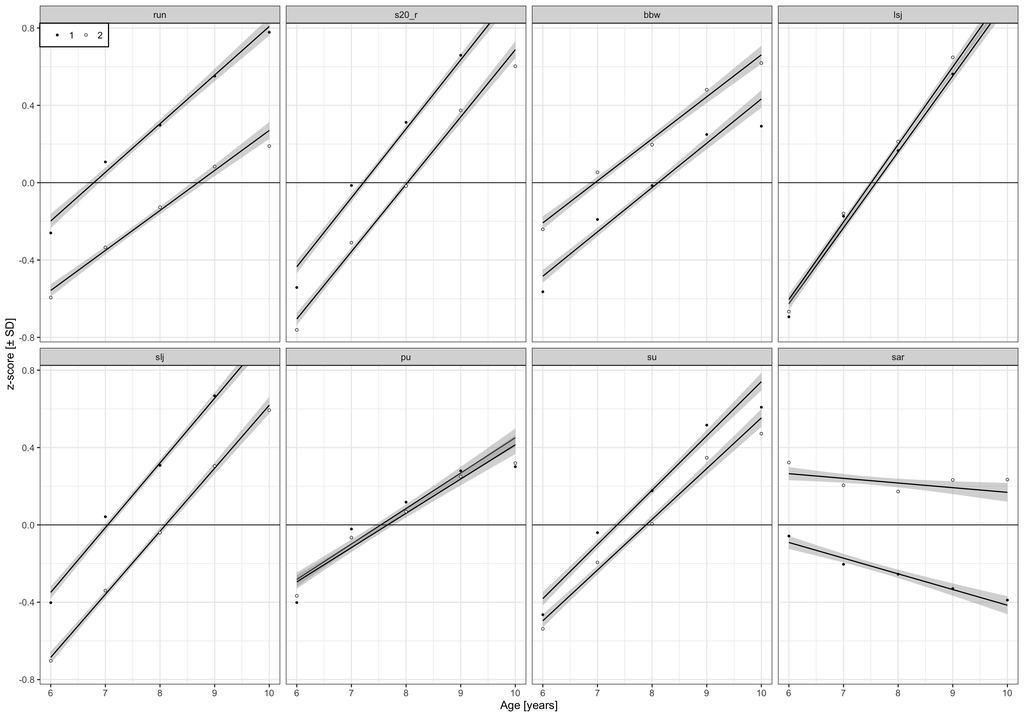

```r
table <-
  dat |>
  mutate(Age = round(age)) |>
  group_by(Age, Sex, Test) %>%
  summarise(N=n(), zScoreM=mean(zScore), SD=sd(zScore),
            CI=1.96*SD/sqrt(N), .groups="drop") |>
  rename(age=Age, zScore=zScoreM)

fig1 <-
  dat |>
  ggplot(aes(x=age, y=zScore, group=Sex, shape=Sex)) +
  facet_wrap(~ Test, nrow=2) +
  geom_smooth(method="lm", se=TRUE,  colour="black", size=.75) +
  geom_point(data=table, fill="white") +
  scale_shape_manual(values=c(16,21)) +
  scale_x_continuous("Age [years]", breaks=seq(6,10,1)) +
  scale_y_continuous("z-score [± SD]") +
  geom_hline(aes(yintercept=0)) +
  coord_cartesian(ylim=c(-0.75,+0.75)) +
  theme_bw(base_size=16) +  theme(legend.justification=c(0,1), legend.position=c(0, 1),
                      legend.background=element_rect(fill="white", color="black"),
                      legend.title=element_blank(), legend.direction="horizontal")
fig1
```

```r
ggsave("figures/btpk22_fig1_keyage.jpg", width=20, height=14, unit="cm")
```

# 6 Linear mixed models

## 6.1 Contrasts and trends

- `contr.sum` uses ‘sum to zero contrasts’, that is returns the difference of factor level means to Grand Mean (except for the last level); Grand Mean is mean of condition means.
- Not much evidence for more than linear trends
- `contr.sdif` tests neighboring levels

```r
contrasts(dat$Sex) <- contr.sum(2)
contrasts(dat$Test) <- MASS::contr.sdif(8)
```

## 6.2 *A priori* LMM

```r
dat$Cohort <-  factor(dat$cohort)
dat$a1 <- dat$age - 8
dat$a2 <- dat$a1*dat$a1
m1 <- lmer(zScore ~ 1 + Test/(Sex*(a1+a2)) + (1 | Child) + (1 | Cohort),
           data=dat, REML=TRUE, control=lmerControl(calc.derivs=FALSE))
print(summary(m1), corr=FALSE)
```

```
Linear mixed model fit by REML ['lmerMod']
Formula: zScore ~ 1 + Test/(Sex * (a1 + a2)) + (1 | Child) + (1 | Cohort)
   Data: dat
Control: lmerControl(calc.derivs = FALSE)

REML criterion at convergence: 348357.4

Scaled residuals:
    Min      1Q  Median      3Q     Max
-4.2508 -0.6167  0.0087  0.6198  5.0738

Random effects:
 Groups   Name        Variance Std.Dev.
 Child    (Intercept) 0.235764 0.48556
 Cohort   (Intercept) 0.005221 0.07226
 Residual             0.632906 0.79555
Number of obs: 136149, groups:  Child, 17831; Cohort, 10

Fixed effects:
                    Estimate Std. Error t value
(Intercept)        0.1515044  0.0238226   6.360
Test2-1            0.0797511  0.0122895   6.489
Test3-2           -0.0520057  0.0122432  -4.248
Test4-3            0.0909588  0.0121556   7.483
Test5-4           -0.0625792  0.0120998  -5.172
Test6-5           -0.0327752  0.0121539  -2.697
Test7-6            0.0085618  0.0122175   0.701
Test8-7           -0.1869073  0.0122700 -15.233
Testrun:Sex1       0.2240085  0.0101446  22.081
Tests20_r:Sex1     0.1586456  0.0101220  15.673
Testbbw:Sex1      -0.1045123  0.0100755 -10.373
Testlsj:Sex1      -0.0226632  0.0100166  -2.263
Testslj:Sex1       0.1839767  0.0100104  18.379
Testpu:Sex1        0.0270460  0.0100821   2.683
Testsu:Sex1        0.0880241  0.0100981   8.717
Testsar:Sex1      -0.2224109  0.0101321 -21.951
Testrun:a1         0.2322985  0.0064590  35.965
Tests20_r:a1       0.3479512  0.0064139  54.250
Testbbw:a1         0.2180448  0.0063353  34.418
Testlsj:a1         0.3859125  0.0063142  61.118
```

[output cut: 13 more lines]

```
Tests20_r:Sex1:a1  0.0009246  0.0063612   0.145
Testbbw:Sex1:a1    0.0010953  0.0062815   0.174
Testlsj:Sex1:a1   -0.0012898  0.0062597  -0.206
Testslj:Sex1:a1    0.0013791  0.0062628   0.220
Testpu:Sex1:a1     0.0003455  0.0063733   0.054
Testsu:Sex1:a1     0.0065628  0.0063600   1.032
Testsar:Sex1:a1   -0.0310553  0.0063418  -4.897
Testrun:Sex1:a2    0.0005325  0.0048426   0.110
Tests20_r:Sex1:a2 -0.0119344  0.0047991  -2.487
Testbbw:Sex1:a2   -0.0135301  0.0046940  -2.882
Testlsj:Sex1:a2    0.0036413  0.0046751   0.779
Testslj:Sex1:a2   -0.0055203  0.0046776  -1.180
Testpu:Sex1:a2    -0.0098304  0.0047936  -2.051
Testsu:Sex1:a2    -0.0082582  0.0047979  -1.721
Testsar:Sex1:a2   -0.0067546  0.0047318  -1.427
```

# 7 Appendix